# 時系列分析 第 6 回 分析例

## 3.2 記述統計量

記述統計量は次である.

```r
stargazer(data.frame(AirPassengers), # 標本
          type = "text", # 出力形式
          summary = TRUE) # 記述統計量
```

```
##
## ==========================================
## Statistic      N   Mean   St. Dev. Min Max
## ------------------------------------------
## AirPassengers 144 280.299 119.966  104 622
## ------------------------------------------
```

## 3.3 データの変換

データはトレンドを含み, 時間と共に変動が大きくなっている. 変動を安定化させるため対数変換を行い, 線形トレンドを除去するために差分を取る.

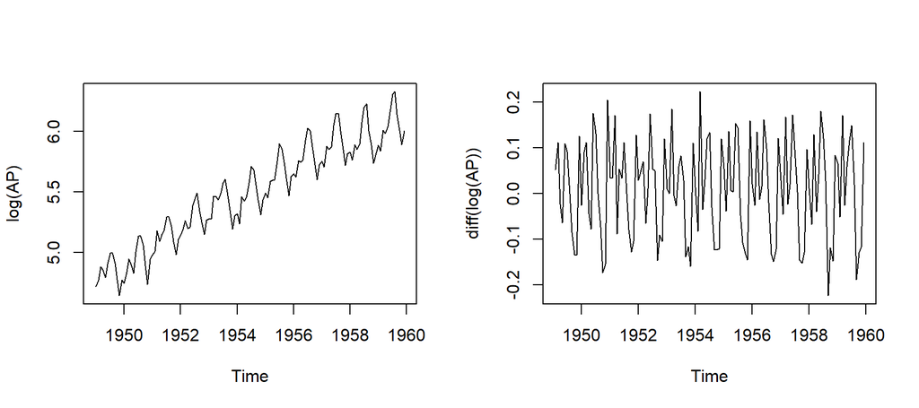

```r
AP <- window(AirPassengers, c(1949, 1), c(1959, 12)) # 1949 年 1 月から 1959 年 12 月までの観測値
par(mfrow = c(1, 2)) # プロット画面を 1 行 2 列に分割
plot(log(AP)) # 対数系列の時系列プロット
plot(diff(log(AP))) # 対数差分系列の時系列プロット
```

対数差分系列は定常過程と考えられるが…

# 4 モデル

## 4.1 自己相関

まず, 対数差分系列の ACF (自己相関関数) と PACF (偏自己相関関数) をプロットする.

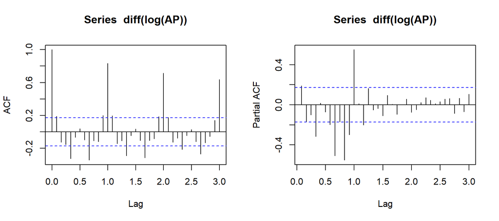

```r
par(mfrow = c(1, 2)) # プロット画面を 1 行 2 列に分割
acf(diff(log(AP)), lag.max = 36) # 自己相関関数
pacf(diff(log(AP)), lag.max = 36) # 偏自己相関関数
```

ACF と PACF より, 自己相関があると判断できる.

```r
(T <- length(diff(log(AP)))) # 標本数
```

```
## [1] 131
```

```r
(m <- round(log(T))) # ラグ m の目安
```

```
## [1] 5
```

上記で作成した関数を用いて, ラグ $5$, $10$, $15$ に対するかばん検定の結果の表を作成する.

```r
fitdf <- 0 # 自由度の減数
lag <- m * (1:3) + fitdf # ラグ m, 2m, 3m
res.port <- sapply(lag, port, x = diff(log(AP)), fitdf = fitdf) # x と fitdf に対して各 lag の port を計算

# 表を作成
digits <- c(0, 2, 0, 4) # 少数点以下の最大表示桁数
col.names <- c("$m$", "$Q(m)$", "自由度", "$p$ 値") # 列名
knitr::kable(t(res.port), # 転置
             digits = digits, # 少数点以下の最大表示桁数
             col.names = col.names, # 列名
             caption = "対数差分系列に対するかばん検定", # 表題
             format.args = list(scientific = FALSE)) # 指数表記をしない
```

対数差分系列に対するかばん検定

| $m$ | $Q(m)$ | 自由度 | $p$ 値 |
| --- | --- | --- | --- |
| 5 | 25.37 | 5 | 0.0001 |
| 10 | 47.40 | 10 | 0.0000 |
| 15 | 165.35 | 15 | 0.0000 |

全てにおいて $p$ 値が $0.01$ より小さいので, 有意水準 $1 \%$ で帰無仮説を棄却できる. つまり, 自己相関があると判断できる.

## 4.2 モデルの決定

対数差分系列の ACF は値が大きく減衰が遅いので, 非定常過程の可能性が高い. さらに, ACF はラグ $12$, $24$, $36$ において大きいので, 対数差分の季節差分系列 (周期 $12$) を考える. 季節差分系列をプロットする.

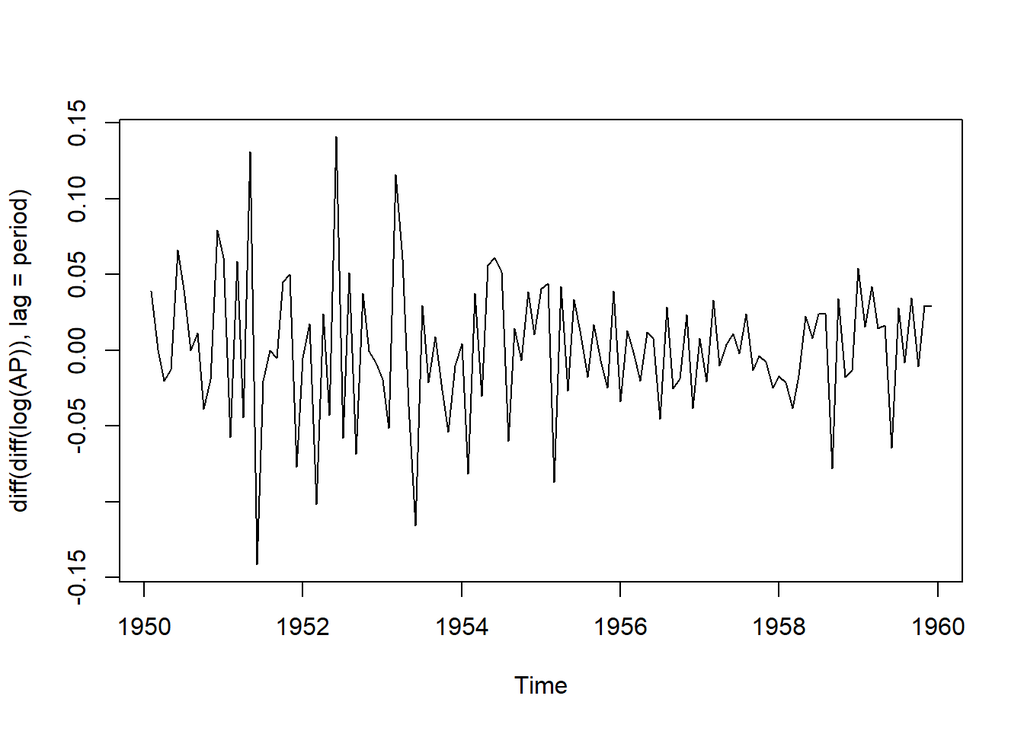

```r
plot(diff(diff(log(AP)), lag = period)) # 時系列プロット
```

季節差分系列の ACF と PACF をプロットする.

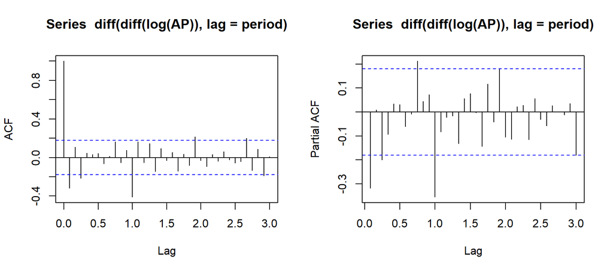

```r
par(mfrow = c(1, 2)) # プロット画面を 1 行 2 列に分割
acf(diff(diff(log(AP)), lag = period), lag.max = 36) # 自己相関関数
pacf(diff(diff(log(AP)), lag = period), lag.max = 36) # 偏自己相関関数
```

ACF と PACF より, 季節差分系列は定常過程と判断する (厳密には定常性の検定を行う必要がある). よって, 対数系列のモデルは SARIMA$(p, 1, q)(P, 1, Q)_{12}$ が妥当である. さらに, ラグ $12$ に強い相関があるから, 単純性を考慮して季節次数 $(P, 1, Q)$ を次とする.

```r
order.s <- c(0, 1, 1) # 季節次数
```

これより, 対数系列に SARIMA$(p, 1, q)(0, 1, 1)_{12}$ を用いて分析を行う.

# 5 推定

パッケージ forecast の関数 auto.arima により計算可能であるが, ここでは用いない.

## 5.1 次数の決定

上記で作成した関数を用いて, モデルの次数を決定する.

```r
Lp <- Lq <- 2 # 最大次数
d <- 1 # 和分次数
res.ic <- ic.sarima(log(AP), Lp, Lq, d, order.s) # 情報量規準を計算

# AIC の表を作成
knitr::kable(res.ic$AIC, # AIC
             digits = c(0, rep(3, Lq + 1)), # 少数点以下の最大表示桁数
             col.names =  c("$p$ $\\backslash$ $q$", 0:Lq), # 列名
             caption = "対数系列に対する SARIMA($p, 1, q$)($0, 1, 1$)$_{12}$ の AIC") # 表題
```

対数系列に対する SARIMA($p, 1, q$)($0, 1, 1$)$_{12}$ の AIC

| $p$ $\backslash$ $q$ | 0 | 1 | 2 |
| --- | --- | --- | --- |
| 0 | -3.260 | -3.343 | -3.328 |
| 1 | -3.340 | -3.330 | -3.315 |
| 2 | -3.325 | -3.339 | -3.325 |

```r
# BIC の表を作成
knitr::kable(res.ic$BIC, # BIC
             digits = c(0, rep(3, Lq + 1)), # 少数点以下の最大表示桁数
             col.names =  c("$p$ $\\backslash$ $q$", 0:Lq), # 列名
             caption = "対数系列に対する SARIMA($p, 1, q$)($0, 1, 1$)$_{12}$ の BIC") # 表題
```

対数系列に対する SARIMA($p, 1, q$)($0, 1, 1$)$_{12}$ の BIC

| $p$ $\backslash$ $q$ | 0 | 1 | 2 |
| --- | --- | --- | --- |
| 0 | -3.217 | -3.280 | -3.244 |
| 1 | -3.277 | -3.246 | -3.210 |
| 2 | -3.241 | -3.234 | -3.199 |

```r
# ARIMA 次数の表を作成
knitr::kable(res.ic$order, # ARMA 次数
             caption = "対数系列に対する SARIMA($p, 1, q$)($0, 1, 1$)$_{12}$ の 次数") # 表題
```

対数系列に対する SARIMA($p, 1, q$)($0, 1, 1$)$_{12}$ の 次数

|  | AR | d | MA |
| --- | --- | --- | --- |
| AIC | 0 | 1 | 1 |
| BIC | 0 | 1 | 1 |

AIC と BIC の両方において, SARIMA$(0, 1, 1)(0, 1, 1)_{12}$ が選択される.

## 5.2 パラメータの推定

SARIMA$(0, 1, 1)(0, 1, 1)_{12}$ を用いて推定を行う. 推定結果は次である.

```r
M1 <- arima(log(AP), # 標本
            order = res.ic$order[1,], # ARIMA 次数
            seasonal = list(order = order.s, period = period), # 季節次数, 周期
            method = "ML") # 最尤法
M1 # 推定結果の表示
```

```
##
## Call:
## arima(x = log(AP), order = res.ic$order[1, ], seasonal = list(order = order.s,
##     period = period), method = "ML")
##
## Coefficients:
##           ma1     sma1
##       -0.3484  -0.5622
## s.e.   0.0943   0.0774
##
## sigma^2 estimated as 0.001313:  log likelihood = 223.63,  aic = -441.26
```

関数 arima において定数項は平均であるから, 和分過程の場合は定数項はない.

係数の有意性について考える. $p$ 値を計算するために, パッケージ lmtest にある関数 coeftest を用いる.

```r
coeftest(M1) # 係数の p 値
```

```
##
## z test of coefficients:
##
##       Estimate Std. Error z value  Pr(>|z|)
## ma1  -0.348425   0.094280 -3.6956 0.0002193 ***
## sma1 -0.562157   0.077429 -7.2603 3.862e-13 ***
## ---
## Signif. codes:  0 '***' 0.001 '**' 0.01 '*' 0.05 '.' 0.1 ' ' 1
```

係数は全て有意水準 $1 \%$ で有意である. 上記より, 原系列を $\{ y_{t} \}$ とすると, 推定されたモデルは次である.

$$(1 - L) (1 - L^{12}) \log y_{t} = (1 -0.348 L) (1 -0.562 L^{12})
\varepsilon_{t}, \quad \sigma^{2} = 0.00131$$

## 5.3 モデル診断

残差の自己相関を調べ, モデルが妥当かどうかを診断する. まずは, 残差を取り出す.

```r
r1 <- residuals(M1) # 残差
```

対数系列と残差の ACF と PACF をプロットする,

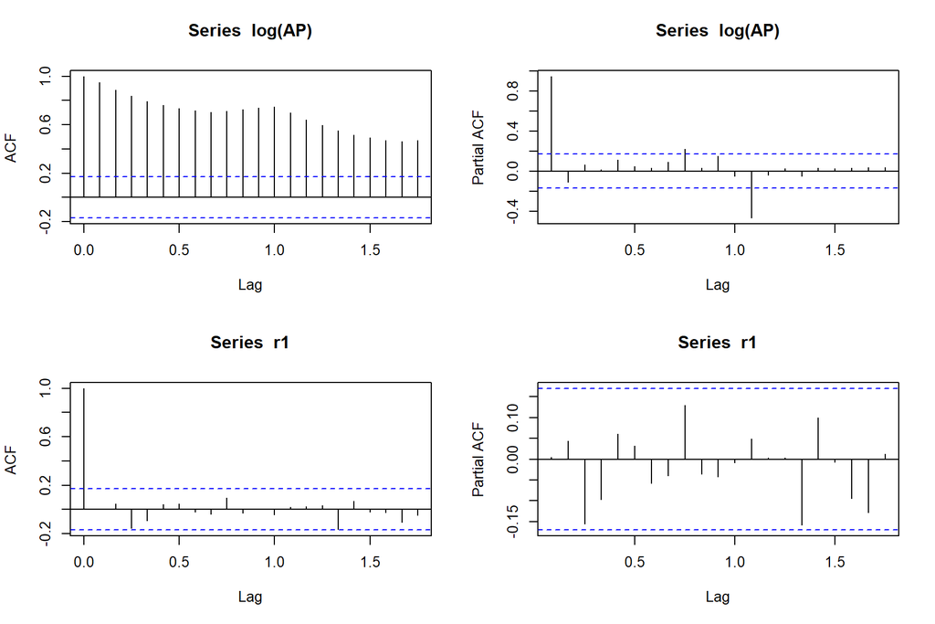

```r
par(mfrow = c(2, 2)) # プロット画面を 2 行 2 列に分割
acf(log(AP)); pacf(log(AP)); # 対数系列
acf(r1); pacf(r1) # 残差
```

自己相関関数と偏自己相関関数より, 残差に自己相関があると判断できない.

かばん検定を行う. 残差に対する検定であるから自由度が減少する.

```r
fitdf <- 2 # 自由度の減数
lag <- 1:(2 * m) + fitdf # ラグ (1, ..., 2m) + fitdf
res.port1 <- sapply(lag, port, x = r1, fitdf = fitdf) # x と fitdf に対して各 lag の port を計算

# 表を作成
knitr::kable(t(res.port1), # 転置
             digits = digits, # 少数点以下の最大表示桁数
             col.names = col.names, # 列名
             caption = "残差に対するかばん検定", # 表題
             format.args = list(scientific = FALSE)) # 指数表記をしない
```

残差に対するかばん検定

| $m$ | $Q(m)$ | 自由度 | $p$ 値 |
| --- | --- | --- | --- |
| 3 | 3.57 | 1 | 0.0588 |
| 4 | 4.81 | 2 | 0.0903 |
| 5 | 5.07 | 3 | 0.1666 |
| 6 | 5.36 | 4 | 0.2521 |
| 7 | 5.42 | 5 | 0.3664 |
| 8 | 5.66 | 6 | 0.4621 |
| 9 | 7.02 | 7 | 0.4269 |
| 10 | 7.15 | 8 | 0.5201 |
| 11 | 7.15 | 9 | 0.6211 |
| 12 | 7.41 | 10 | 0.6862 |

全ての自由度において $p$ 値が $0.05$ より大きいので, 有意水準 $5 \%$ で帰無仮説を棄却できない. つまり, 残差に自己相関があると判断できないので, モデルは妥当である.

# 6 予測

パッケージ forecast を用いて予測を行う. 推定されたモデルを用いて $12$ 期先予測を行う.

```r
n.ahead <- 12 # 期先
f1 <- forecast(M1, h = n.ahead) # 予測
```

対数系列の結果を原系列の結果に変換する.

```r
f1$x <- exp(f1$x) # 観測値
f1$mean <- exp(f1$mean) # 予測値
f1$lower <- exp(f1$lower) # 信頼区間の下限
f1$upper <- exp(f1$upper) # 信頼区間の上限
```

予測値と観測値を重ねてプロットする. 図を重ねる場合は, $y$ 軸の範囲を合わせる必要がある.

```r
range(AirPassengers) # 値域
```

```
## [1] 104 622
```

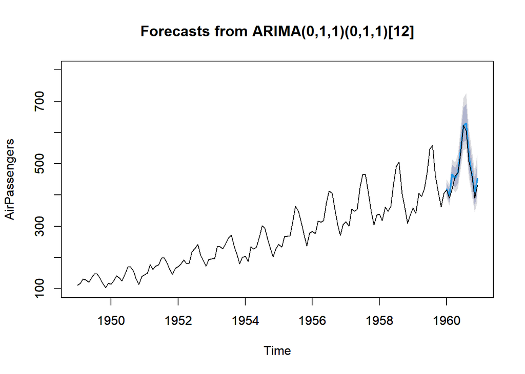

```r
ylim <- c(100, 800) # y 軸の範囲
plot(f1, # 予測値
     ylim = ylim) # y 軸の範囲
par(new = T) # 次のプロットを重ねる
plot(AirPassengers, # 観測値
     ylim = ylim) # y 軸の範囲
```

予測部分のみをプロットする. 月次データの場合は目盛が不自然なので変更する.

```r
AP1 <- window(AirPassengers, c(1960, 1), c(1960, 12)) # 予測部分の観測値
xlim <- c(1960, 1960 + 11 / 12) # x 軸の範囲
range(AP1) # 値域
```

```
## [1] 390 622
```

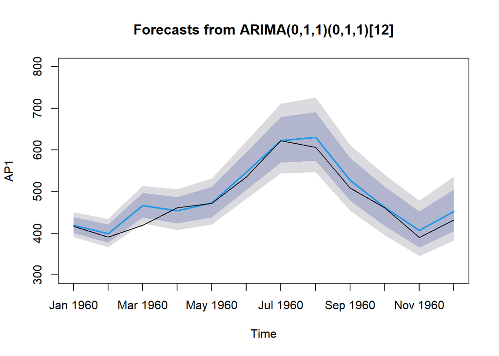

```r
ylim <- c(300, 800) # y 軸の範囲
plot(f1, # 予測値
     xlim = xlim, # x 軸の範囲
     ylim = ylim, # y 軸の範囲
     axes = FALSE, # 目盛を表示しない
     frame.plot = TRUE) # 枠を表示する
par(new = T) # 次のプロットを重ねる
plot(AP1, # 観測値
     xlim = xlim, # x 軸の範囲
     ylim = ylim, # y 軸の範囲
     axes = FALSE, # 目盛を表示しない
     frame.plot = TRUE) # 枠を表示する

# x軸の目盛を変更
xat <- 1960 + (0:11) / 12 # x 軸の目盛の位置
axis(1, at = xat, labels = paste(month.abb, 1960)) # x 軸に目盛を追加

# y軸の目盛を変更
yat <- (3:8) * 100 # y 軸の目盛の位置
axis(2, at = yat, labels = yat) # y 軸に目盛を追加
```

予測値と観測値の差の 2 乗の平均は次である.

```r
mean((f1$mean - AP1)^2)
```

```
## [1] 345.7714
```

# 7 補足: 変数の追加

ダミー変数などの変数を追加する方法を紹介する. 例として, ダミー変数を用いる.

```r
# 夏季ダミー
D.summer <- rep(rep(c(0, 1, 0), c(6, 3, 3)), # 0, 1, 0 を 6, 3, 3 回繰り返す (0, 0, 0, 0, 0, 0, 1, 1, 1, 0, 0, 0)
                length.out = length(log(AP))) # ベクトルの長さ
# 8 月ダミー
D.aug <- rep(rep(c(0, 1, 0), c(7, 1, 4)), # 0, 1, 0 を 7, 1, 4 回繰り返す (0, 0, 0, 0, 0, 0, 0, 1, 0, 0, 0, 0)
             length.out = length(log(AP))) # ベクトルの長さ
```

変数が 1 つの場合は次である.

```r
M2 <- arima(log(AP), # 標本
            order = res.ic$order[1,], # ARIMA 次数
            seasonal = list(order = order.s, period = period), # 季節次数, 周期
            xreg = D.summer, # 変数を追加
            method = "ML") # 最尤法
M2 # 推定結果の表示
```

```
##
## Call:
## arima(x = log(AP), order = res.ic$order[1, ], seasonal = list(order = order.s,
##     period = period), xreg = D.summer, method = "ML")
##
## Coefficients:
##           ma1     sma1   D.summer
##       -0.3485  -0.5623     5.6598
## s.e.   0.0943   0.0774  5731.9164
##
## sigma^2 estimated as 0.001313:  log likelihood = 223.63,  aic = -439.26
```

変数が複数の場合は次である.

```r
M3 <- arima(log(AP), # 標本
            order = res.ic$order[1,], # ARIMA 次数
            seasonal = list(order = order.s, period = period), # 季節次数, 周期
            xreg = cbind(D.summer, D.aug), # 複数の変数を追加
            method = "ML") # 最尤法
M3 # 推定結果の表示
```

```
##
## Call:
## arima(x = log(AP), order = res.ic$order[1, ], seasonal = list(order = order.s,
##     period = period), xreg = cbind(D.summer, D.aug), method = "ML")
##
## Coefficients:
##           ma1     sma1   D.summer      D.aug
##       -0.3485  -0.5623     5.6374      0.067
## s.e.   0.0943   0.0774  9044.8350  15645.851
##
## sigma^2 estimated as 0.001313:  log likelihood = 223.63,  aic = -437.26
```